# Problem Set 2 - College Admissions Data

SI 544 Instruction Team

10/25/2019

## Introduction

The total score for this assignment will be 100 points, consisting of: - 90 points: Homework Questions - 10 points: Overall quality of spelling, grammar, punctuation, etc. of written sentences.

As in lecture and discussion, there are several ways to approach and answer these questions! There may not be a “best solution”, but instead a variety of ways to interpret and analyze a given task. Be thoughtful in your responses below your code to explain why you chose the methods and representations in your analysis when prompted for a response.

For further reference regarding quality writing, feel free to refer to Strunk & White’s Elements of Style: https://drive.google.com/file/d/1L0P7xJwjUGBvyb49mL3dw1Bt7hzRTiTl/view?usp=sharing

## The Data

The data set for this assignment consists of college admissions data. It comes from an open data set available via https://www.kaggle.com/mohansacharya/graduate-admissions .

The dataset contains several parameters which are considered important during the application for Masters Programs. The parameters included are:

1. GRE Scores ( out of 340 )
2. TOEFL Scores ( out of 120 )
3. University Rating ( out of 5 )
4. Statement of Purpose and Letter of Recommendation Strength ( out of 5 )
5. Undergraduate GPA ( out of 10 )
6. Research Experience ( either 0 or 1 )
7. Chance of Admit ( ranging from 0 to 1 )

The full citation for the data is:

Mohan S Acharya, Asfia Armaan, Aneeta S Antony : A Comparison of Regression Models for Prediction of Graduate Admissions, IEEE International Conference on Computational Intelligence in Data Science 2019.

Copy the file ‘Admission_Predict.csv’ from the read only folder into your working directory, fill in your name into the string assigned to *MY_UNIQNAME* , then execute the following code block to load the packages and data into your environment.

```r
MY_UNIQNAME = "Tabbie"

# Initial setup for our environment
library(tidyverse)
```

```r
library(moderndive)
library(ggplot2)

# Reading the file in from your working directory
data <- read_csv('Admission_Predict.csv')
data <- data %>% select(gre = "GRE Score", toefl = "TOEFL Score", university_rating = `University Rating`, sop = SOP, lor = LOR, cgpa = CGPA, research=Research,admit = `Chance of Admit`) %>% mutate(research=factor(research))
```

### Question 1 (5 points)

Explain what the previous R code block does.

#### Q1 Response:

In the above code from the original dataframe a new dataframe is made named data. From the original dataframe the following columns are selected and renamed; GRE Score is renamed as gre, TOEFL Score is renamed as toefl, University Rating is renamed as university_rating, SOP as sop, LOR as lor, CGPA as cgpa, Research as research, Chance of Admit as admit. Then the mutate function is used to create a new column research with factor type values.

### Question 2 (10 points)

Describe the shape of the distribution of the chance of admission. If you decide to use a histogram choose your width of your bins carefully.

```r
data %>% summarise(max_val = max(admit), min_val = min(admit), mean_val = mean(admit), median_val = median(admit))
```

```
## # A tibble: 1 x 4
##   max_val min_val mean_val median_val
##     <dbl>   <dbl>    <dbl>      <dbl>
## 1    0.97    0.34    0.724       0.73
```

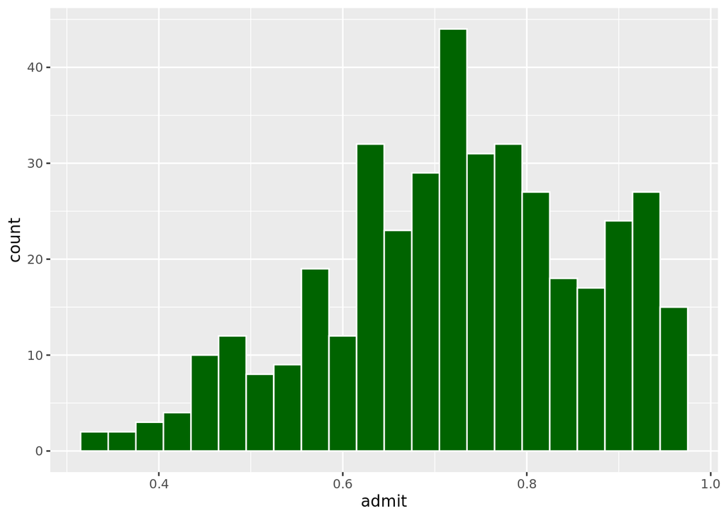

```r
ggplot(data = data, mapping = aes(x = admit)) + geom_histogram(bins = 20, binwidth = 0.03, color = 'white', fill = 'darkgreen')
```

#### Q2 Response:

The distribution is slightly skewed to the left with a number of lower values of the data on the left side of the histogram. But since a large number of values are seen on the right side of the histogram the skewness is balanced out. We can also notice that the mean and median are fairly same upto the first decimal position.

### Question 3 (10 points)

Create a plot of chance of admission as the outcome variable vs. GRE score as the explanatory variable that shows the line of best fit. Label your axes and use a title or caption for the visualization. Does the lowest GRE score have the least chance of admission?

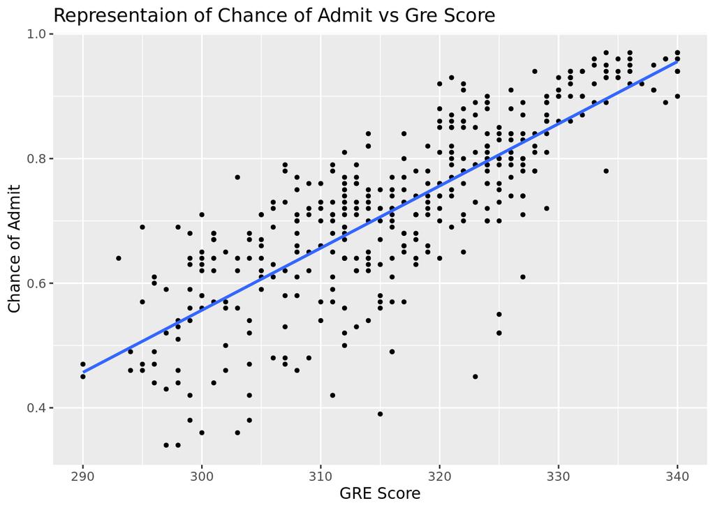

```r
ggplot(data = data, mapping = aes(x = gre, y = admit)) +
  geom_point(size = 1) +
  labs(x = "GRE Score", y = "Chance of Admit", title = 'Representaion of Chance of Admit vs Gre Score') +
  geom_smooth(method="lm",se=FALSE)
```

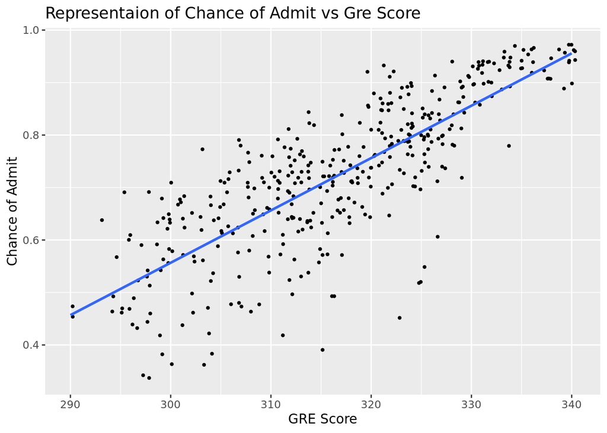

```r
ggplot(data = data, mapping = aes(x = gre, y = admit)) +
  geom_jitter(size = 0.8) +
  labs(x = "GRE Score", y = "Chance of Admit", title = 'Representaion of Chance of Admit vs Gre Score') +
  geom_smooth(method="lm",se=FALSE)
```

### Question 4 (15 points)

Create a regression model using chance of admission as the outcome variable and GRE score as the explanatory variable. What are the estimates for the coefficients (intercept and GRE score)?

```r
# Get regression model
data_model1 <- lm(admit ~ gre, data = data)

summary(data_model1)
```

```
##
## Call:
## lm(formula = admit ~ gre, data = data)
##
## Residuals:
##      Min       1Q   Median       3Q      Max
## -0.33613 -0.04604  0.00408  0.05644  0.18339
##
## Coefficients:
##               Estimate Std. Error t value Pr(>|t|)
## (Intercept) -2.4360842  0.1178141  -20.68   <2e-16 ***
## gre          0.0099759  0.0003716   26.84   <2e-16 ***
## ---
## Signif. codes:  0 '***' 0.001 '**' 0.01 '*' 0.05 '.' 0.1 ' ' 1
##
## Residual standard error: 0.08517 on 398 degrees of freedom
## Multiple R-squared:  0.6442, Adjusted R-squared:  0.6433
## F-statistic: 720.6 on 1 and 398 DF,  p-value: < 2.2e-16
```

```r
# Get regression table:
get_regression_table(data_model1)
```

```
## # A tibble: 2 x 7
##   term      estimate std_error statistic p_value lower_ci upper_ci
##   <chr>        <dbl>     <dbl>     <dbl>   <dbl>    <dbl>    <dbl>
## 1 intercept    -2.44     0.118     -20.7       0   -2.67    -2.20
## 2 gre           0.01     0          26.8       0    0.009    0.011
```

#### Q4 Response:

The estimates for the coefficients are as follows: Intercept = -2.44 Gre score = 0.01

### Question 5 (10 points)

Create a visualization that shows the relationship between Cumulative GPA and the Chance of Admission.  
Use two different colors of lines to show the difference that having research experience makes.  
Describe the effect that having research experience appears to have.

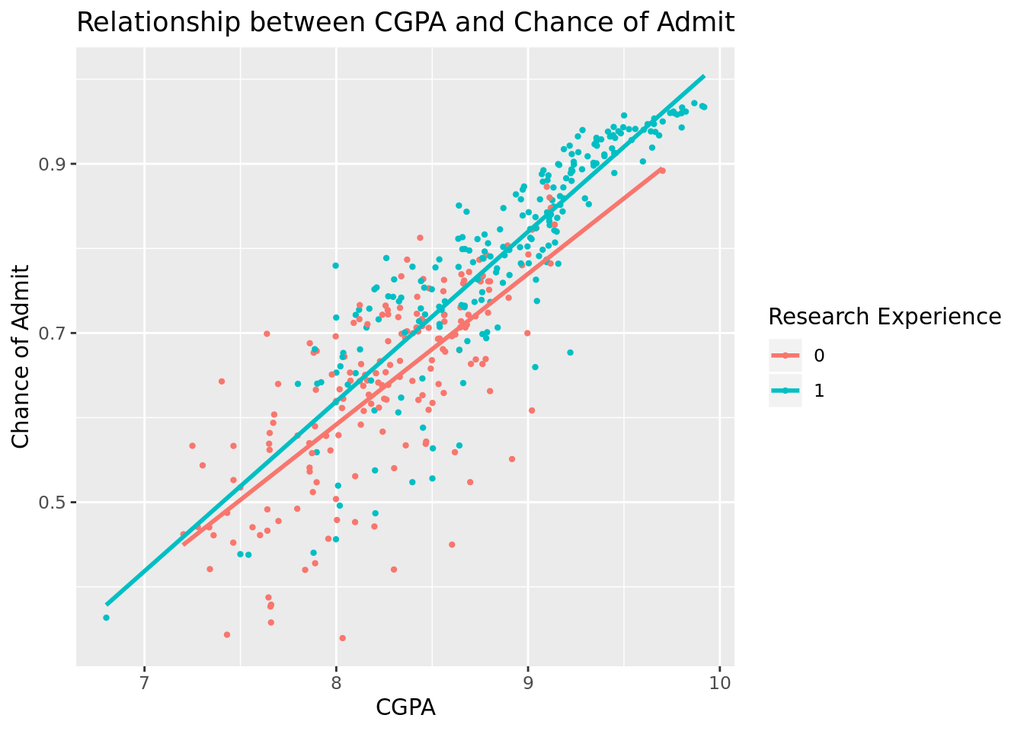

```r
ggplot(data = data, mapping = aes(x = cgpa, y = admit, color = research)) +
  geom_jitter(size = 0.8) +
  labs(x = "CGPA", y = "Chance of Admit", color = "Research Experience", title = "Relationship between CGPA and Chance of Admit") +
  geom_smooth(method="lm",se=FALSE)
```

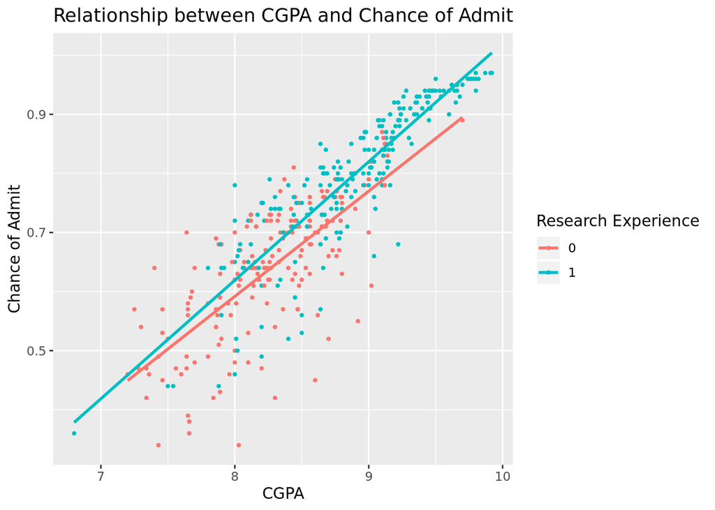

```r
ggplot(data = data, mapping = aes(x = cgpa, y = admit, color = research)) +
  geom_point(size = 0.8) +
  labs(x = "CGPA", y = "Chance of Admit", color = "Research Experience", title = "Relationship between CGPA and Chance of Admit") +
  geom_smooth(method="lm",se=FALSE)
```

#### Q5 Response:

It’s generally seen that those applicants having higher CGPA along with research experience have greater chance of admit. Thus, having a research experience positively influence the chance of admit.

### Question 6 (15 points)

Create a regression model that uses chance of admission as the outcome variable and Cumulative GPA *and* research experience as the explanatory variables. What is the expected (estimated) value of the chance of admission for an individual with a cumulative GPA of 9.0 who has research experience.

```r
# Get regression model
data_model2 <- lm(admit ~ cgpa*research, data = data)

summary(data_model2)
```

```
##
## Call:
## lm(formula = admit ~ cgpa * research, data = data)
##
## Residuals:
##       Min        1Q    Median        3Q       Max
## -0.257202 -0.026271  0.007943  0.042733  0.172284
##
## Coefficients:
##                Estimate Std. Error t value Pr(>|t|)
## (Intercept)    -0.83351    0.08936  -9.328   <2e-16 ***
## cgpa            0.17817    0.01080  16.490   <2e-16 ***
## research1      -0.15215    0.11669  -1.304    0.193
## cgpa:research1  0.02243    0.01371   1.637    0.102
## ---
## Signif. codes:  0 '***' 0.001 '**' 0.01 '*' 0.05 '.' 0.1 ' ' 1
##
## Residual standard error: 0.06756 on 396 degrees of freedom
## Multiple R-squared:  0.7772, Adjusted R-squared:  0.7756
## F-statistic: 460.6 on 3 and 396 DF,  p-value: < 2.2e-16
```

```r
# Get regression table:
get_regression_table(data_model2)
```

```
## # A tibble: 4 x 7
##   term           estimate std_error statistic p_value lower_ci upper_ci
##   <chr>             <dbl>     <dbl>     <dbl>   <dbl>    <dbl>    <dbl>
## 1 intercept        -0.834     0.089     -9.33   0       -1.01    -0.658
## 2 cgpa              0.178     0.011     16.5    0        0.157    0.199
## 3 research1        -0.152     0.117     -1.30   0.193   -0.382    0.077
## 4 cgpa:research1    0.022     0.014      1.64   0.102   -0.005    0.049
```

### Question 7 (10 points)

Is Cumulative GPA a good predictor of GRE score? Explain your answer.

```r
# Get regression model
data_model3 <- lm(gre ~ cgpa, data = data)

summary(data_model3)
```

```
##
## Call:
## lm(formula = gre ~ cgpa, data = data)
##
## Residuals:
##      Min       1Q   Median       3Q      Max
## -18.1453  -4.2984   0.5042   3.7769  26.7925
##
## Coefficients:
##             Estimate Std. Error t value Pr(>|t|)
## (Intercept) 178.9771     4.5987   38.92   <2e-16 ***
## cgpa         16.0288     0.5335   30.04   <2e-16 ***
## ---
## Signif. codes:  0 '***' 0.001 '**' 0.01 '*' 0.05 '.' 0.1 ' ' 1
##
## Residual standard error: 6.355 on 398 degrees of freedom
## Multiple R-squared:  0.694,  Adjusted R-squared:  0.6932
## F-statistic: 902.6 on 1 and 398 DF,  p-value: < 2.2e-16
```

```r
# Get regression table:
get_regression_table(data_model3)
```

```
## # A tibble: 2 x 7
##   term      estimate std_error statistic p_value lower_ci upper_ci
##   <chr>        <dbl>     <dbl>     <dbl>   <dbl>    <dbl>    <dbl>
## 1 intercept    179.      4.60       38.9       0    170.     188.
## 2 cgpa          16.0     0.534      30.0       0     15.0     17.1
```

#### Q7 Response:

Considering the R- squared value which is 0.7, CGPA is a good predictor of GRE score.

### Question 8 (15 points)

Which is more important (for the purposes of being admitted): (a) to have a strong letter of reference or (b) to have a strong statement of purpose? Explain your answer.

```r
# Get regression model
data_model4 <- lm(admit ~ lor + sop, data = data)

summary(data_model4)
```

```
##
## Call:
## lm(formula = admit ~ lor + sop, data = data)
##
## Residuals:
##      Min       1Q   Median       3Q      Max
## -0.43780 -0.05457  0.01461  0.06212  0.28213
##
## Coefficients:
##             Estimate Std. Error t value Pr(>|t|)
## (Intercept) 0.324571   0.020048  16.190  < 2e-16 ***
## lor         0.060028   0.008041   7.466 5.30e-13 ***
## sop         0.056627   0.007175   7.892 2.92e-14 ***
## ---
## Signif. codes:  0 '***' 0.001 '**' 0.01 '*' 0.05 '.' 0.1 ' ' 1
##
## Residual standard error: 0.09869 on 397 degrees of freedom
## Multiple R-squared:  0.5235, Adjusted R-squared:  0.5211
## F-statistic: 218.1 on 2 and 397 DF,  p-value: < 2.2e-16
```

```r
# Get regression table:
get_regression_table(data_model4)
```

```
## # A tibble: 3 x 7
##   term      estimate std_error statistic p_value lower_ci upper_ci
##   <chr>        <dbl>     <dbl>     <dbl>   <dbl>    <dbl>    <dbl>
## 1 intercept    0.325     0.02      16.2        0    0.285    0.364
## 2 lor          0.06      0.008      7.47       0    0.044    0.076
## 3 sop          0.057     0.007      7.89       0    0.043    0.071
```

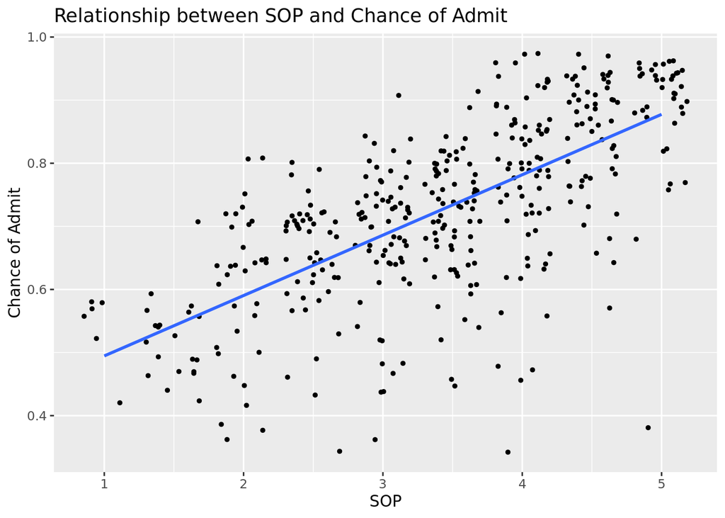

```r
ggplot(data = data, mapping = aes(x = sop, y = admit)) +
  geom_jitter(size = 1) +
  labs(x = "SOP", y = "Chance of Admit", title = "Relationship between SOP and Chance of Admit") +
  geom_smooth(method="lm",se=FALSE)
```

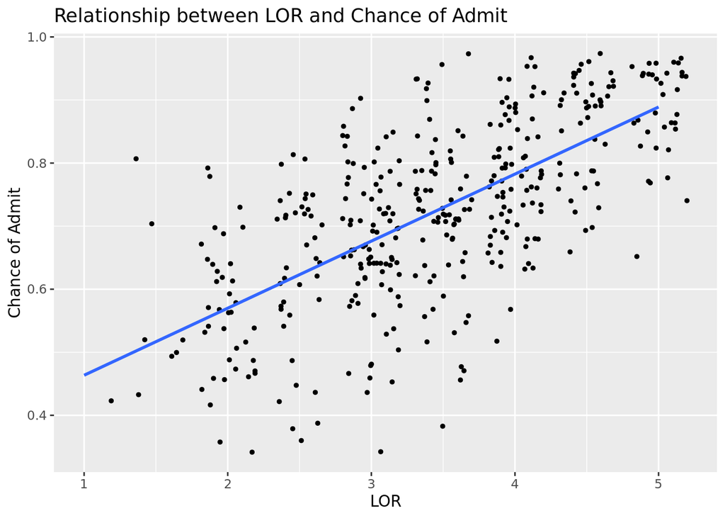

```r
ggplot(data = data, mapping = aes(x = lor, y = admit)) +
  geom_jitter(size = 1) +
  labs(x = "LOR", y = "Chance of Admit", title = "Relationship between LOR and Chance of Admit") +
  geom_smooth(method="lm",se=FALSE)
```

#### Q8 Response:

Considering the R- squared value that is 0.5 and looking the slopes of each graph, it is concluded that both lor and sop are almost equally important for the purpose of being admitted.